# Analysis of Body Mass Index and Body Fat Percentage

# Plots for more than 2 variables

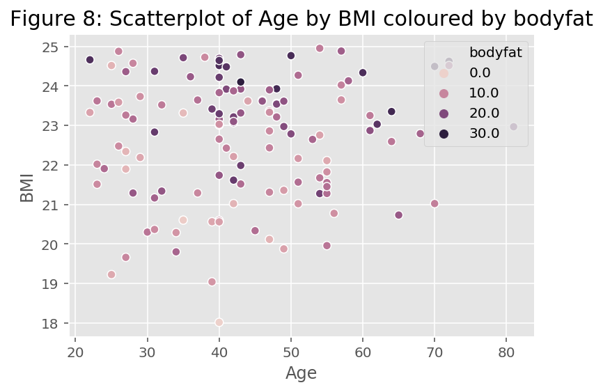

```python
# c[(c.BMI <= 25)] = 'Overweight'
# Getting the index of those who work in the government
result_mask = (c['Result'])

# creating a dataframe of those who work in the government
result = c[result_mask]

# creating a scatterplot
sns.scatterplot(result['Age'], result['BMI'], hue = result['bodyfat'])
plt.title('Figure 8: Scatterplot of Age by BMI coloured by bodyfat', fontsize = 15);
plt.legend(loc = 'upper right')
plt.show();
```

We will be plotting a scatterplot of Height by Weight, coloured by BMI and all of them are related. We can also see that it might hold a positive co-relation.

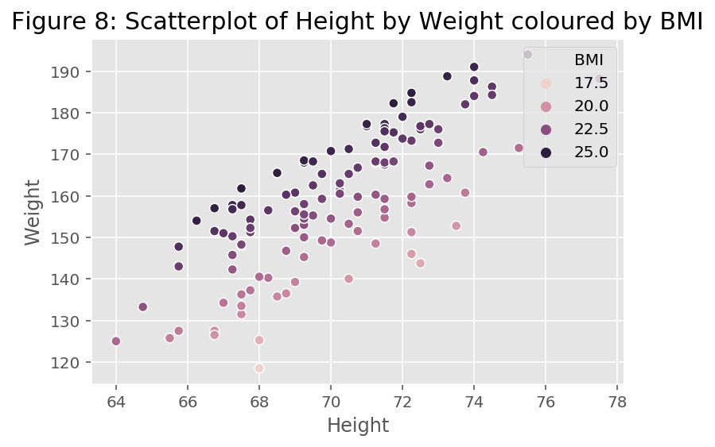

```python
# Getting the index of those who work in the government
gov_mask = (c['Result'])

# creating a dataframe of those who work in the government
gov = c[gov_mask]

# creating a scatterplot
sns.scatterplot(gov['Height'], gov['Weight'], hue = gov['BMI'])
plt.title('Figure 8: Scatterplot of Height by Weight coloured by BMI', fontsize = 15);
plt.legend(loc = 'upper right')
plt.show();
```

# Statistical Modeling and Performance Evaluation

# Full Model

We will begin by fitting a multiple linear regression that predicts the "BMI" using all of the available features. Let's take a look at the clean data.

```python
c.head()
```

|  | Density | bodyfat | Age | Weight | Height | Neck | Chest | Abdomen | Hip | Thigh | Knee | Ankle | Biceps | Forearm | Wrist | BMI | Result |
| --- | --- | --- | --- | --- | --- | --- | --- | --- | --- | --- | --- | --- | --- | --- | --- | --- | --- |
| 0 | 1.0708 | 12.3 | 23 | 154.25 | 67.75 | 36.2 | 93.1 | 85.2 | 94.5 | 59.0 | 37.3 | 21.9 | 32.0 | 27.4 | 17.1 | 23.621987 | True |
| 1 | 1.0853 | 6.1 | 22 | 173.25 | 72.25 | 38.5 | 93.6 | 83.0 | 98.7 | 58.7 | 37.3 | 23.4 | 30.5 | 28.9 | 18.2 | 23.329606 | True |
| 2 | 1.0414 | 25.3 | 22 | 154.00 | 66.25 | 34.0 | 95.8 | 87.9 | 99.2 | 59.6 | 38.9 | 24.0 | 28.8 | 25.2 | 16.6 | 24.663733 | True |
| 3 | 1.0751 | 10.4 | 26 | 184.75 | 72.25 | 37.4 | 101.8 | 86.4 | 101.2 | 60.1 | 37.3 | 22.8 | 32.4 | 29.4 | 18.2 | 24.878180 | True |
| 4 | 1.0340 | 28.7 | 24 | 184.25 | 71.25 | 34.4 | 97.3 | 100.0 | 101.9 | 63.2 | 42.2 | 24.0 | 32.2 | 27.7 | 17.7 | 25.512183 | False |

When constructing a regression model, we can manually add all the independent features but as there are quite a few, we can use some string function methods as you can see below:

```python
formula_string_indep_vars = ' + '.join(c.drop(columns='BMI').columns)
formula_string = 'BMI ~ ' + formula_string_indep_vars
print('formula_string: ', formula_string)
```

```
formula_string:  BMI ~ Density + bodyfat + Age + Weight + Height + Neck + Chest + Abdomen + Hip + Thigh + Knee + Ankle + Biceps + Forearm + Wrist + Result
```

In the code chunk below, we first use the get_dummies() function in Pandas for one-hot-encoding of categorical features and then we construct a new formula string with the encoded features.

```python
c_encoded = pd.get_dummies(c, drop_first = True)
c_encoded.head()
```

|  | Density | bodyfat | Age | Weight | Height | Neck | Chest | Abdomen | Hip | Thigh | Knee | Ankle | Biceps | Forearm | Wrist | BMI | Result |
| --- | --- | --- | --- | --- | --- | --- | --- | --- | --- | --- | --- | --- | --- | --- | --- | --- | --- |
| 0 | 1.0708 | 12.3 | 23 | 154.25 | 67.75 | 36.2 | 93.1 | 85.2 | 94.5 | 59.0 | 37.3 | 21.9 | 32.0 | 27.4 | 17.1 | 23.621987 | True |
| 1 | 1.0853 | 6.1 | 22 | 173.25 | 72.25 | 38.5 | 93.6 | 83.0 | 98.7 | 58.7 | 37.3 | 23.4 | 30.5 | 28.9 | 18.2 | 23.329606 | True |
| 2 | 1.0414 | 25.3 | 22 | 154.00 | 66.25 | 34.0 | 95.8 | 87.9 | 99.2 | 59.6 | 38.9 | 24.0 | 28.8 | 25.2 | 16.6 | 24.663733 | True |
| 3 | 1.0751 | 10.4 | 26 | 184.75 | 72.25 | 37.4 | 101.8 | 86.4 | 101.2 | 60.1 | 37.3 | 22.8 | 32.4 | 29.4 | 18.2 | 24.878180 | True |
| 4 | 1.0340 | 28.7 | 24 | 184.25 | 71.25 | 34.4 | 97.3 | 100.0 | 101.9 | 63.2 | 42.2 | 24.0 | 32.2 | 27.7 | 17.7 | 25.512183 | False |

But, we don't have any categorical features and hence there is no difference in the output and it is same as earlier.

```python
formula_string_indep_vars_encoded = ' + '.join(c_encoded.drop(columns='BMI').columns)
formula_string_encoded = 'BMI ~ ' + formula_string_indep_vars_encoded
print('formula_string_encoded: ', formula_string_encoded)
```

```
formula_string_encoded:  BMI ~ Density + bodyfat + Age + Weight + Height + Neck + Chest + Abdomen + Hip + Thigh + Knee + Ankle + Biceps + Forearm + Wrist + Result
```

Again, no difference because of absence of categorical features.

```python
print("No categorical variables and hence the same result")
```

```
No categorical variables and hence the same result
```

Just to explore a bit more, we are adding two interaction terms to our model. Let's try adding the interaction of "Height" feature with "Neck" and "Chest".

Now that we have defined our statistical model formula as a Python string, we fit an OLS (ordinary least squares) model to our encoded data.

```python
formula_string_encoded = formula_string_encoded + '+ Neck:Height + Chest:Height '
print('formula_string_encoded', formula_string_encoded)
```

```
formula_string_encoded BMI ~ Density + bodyfat + Age + Weight + Height + Neck + Chest + Abdomen + Hip + Thigh + Knee + Ankle + Biceps + Forearm + Wrist + Result+ Neck:Height + Chest:Height
```

```python
new_model = sm.formula.ols(formula=formula_string_encoded, data=c_encoded)
###
new_model_fitted = new_model.fit()
###
print(new_model_fitted.summary())
```

```
                            OLS Regression Results
==============================================================================
Dep. Variable:                    BMI   R-squared:                       0.932
Model:                            OLS   Adj. R-squared:                  0.927
Method:                 Least Squares   F-statistic:                     178.0
Date:                Sun, 27 Oct 2019   Prob (F-statistic):          4.44e-125
Time:                        21:33:19   Log-Likelihood:                -586.79
No. Observations:                 252   AIC:                             1212.
Df Residuals:                     233   BIC:                             1279.
Df Model:                          18
Covariance Type:            nonrobust
==================================================================================
                     coef    std err          t      P>|t|      [0.025      0.975]
----------------------------------------------------------------------------------
Intercept        100.2833    109.433      0.916      0.360    -115.322     315.889
Result[T.True]     0.9015      0.525      1.718      0.087      -0.132       1.935
Density           81.7451     58.482      1.398      0.164     -33.477     196.967
bodyfat            0.2017      0.134      1.501      0.135      -0.063       0.467
Age                0.0059      0.020      0.299      0.766      -0.033       0.045
Weight             0.3601      0.037      9.837      0.000       0.288       0.432
Height            -2.4180      1.088     -2.222      0.027      -4.562      -0.274
Neck             -28.4929      2.673    -10.661      0.000     -33.758     -23.227
Chest              9.9853      0.699     14.279      0.000       8.608      11.363
Abdomen           -0.2012      0.066     -3.055      0.003      -0.331      -0.071
Hip               -0.2503      0.091     -2.760      0.006      -0.429      -0.072
Thigh             -0.0441      0.089     -0.494      0.622      -0.220       0.132
Knee               0.4606      0.147      3.132      0.002       0.171       0.750
Ankle             -0.2391      0.134     -1.786      0.075      -0.503       0.025
Biceps            -0.1674      0.104     -1.605      0.110      -0.373       0.038
Forearm            0.0259      0.123      0.210      0.834      -0.216       0.268
Wrist              0.1945      0.332      0.586      0.558      -0.459       0.848
Neck:Height        0.4039      0.038     10.519      0.000       0.328       0.480
Chest:Height      -0.1450      0.010    -14.772      0.000      -0.164      -0.126
==============================================================================
Omnibus:                       49.322   Durbin-Watson:                   1.895
Prob(Omnibus):                  0.000   Jarque-Bera (JB):              433.643
Skew:                           0.407   Prob(JB):                     6.85e-95
Kurtosis:                       9.375   Cond. No.                     5.56e+06
==============================================================================

Warnings:
[1] Standard Errors assume that the covariance matrix of the errors is correctly specified.
[2] The condition number is large, 5.56e+06. This might indicate that there are
strong multicollinearity or other numerical problems.
```

Let's plot actual BMI values vs predicted values

[figure not shown]

```python
def plot_line(axis, slope, intercept, **kargs):
    xmin, xmax = axis.get_xlim()
    plt.plot([xmin, xmax], [xmin*slope+intercept, xmax*slope+intercept], **kargs)

# Creating scatter plot
plt.scatter(c_encoded['BMI'], new_model_fitted.fittedvalues, alpha=0.3);
plot_line(axis=plt.gca(), slope=1, intercept=0, c="red");
plt.xlabel('BMI');
plt.ylabel('Expected BMI');
plt.title('Figure : Scatterplot of age against expected BMI', fontsize=15);
plt.show();
```

# Full Model Diagnostic Checks

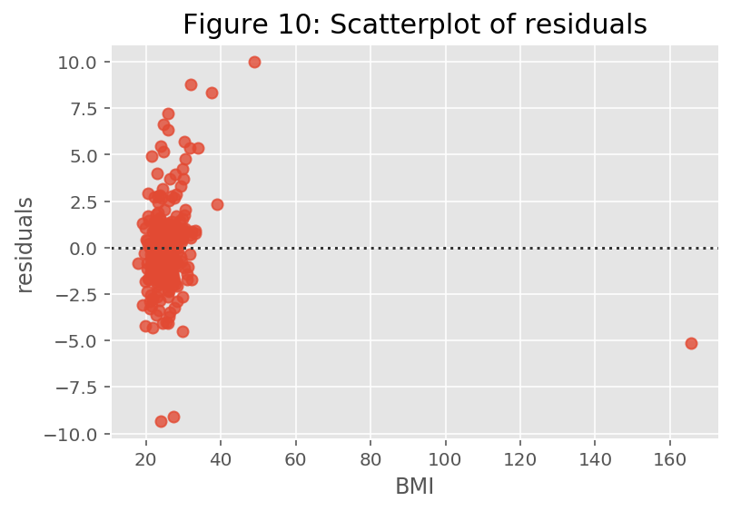

```python
sns.residplot(x=c_encoded['BMI'], y=new_model_fitted.fittedvalues);
plt.ylabel('residuals')
plt.title('Figure 10: Scatterplot of residuals', fontsize=15)
plt.show();
```

From Figure , we see that the residuals appear mostly random and centered around 0. The exception is those above the BMI of 40 I think for whom the model predicts higher BMI. Let's also look at the histogram of the residuals.

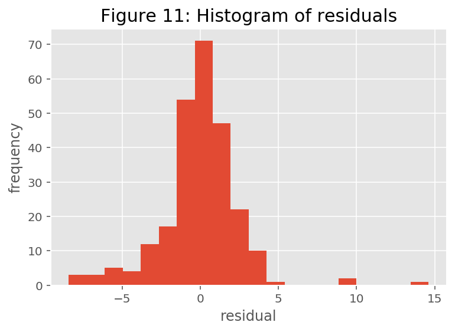

```python
residuals = c_encoded['BMI'] - new_model_fitted.fittedvalues
plt.hist(residuals, bins = 20);
plt.xlabel('residual');
plt.ylabel('frequency');
plt.title('Figure 11: Histogram of residuals', fontsize=15);
plt.show();
```

From Figure 11, the histogram of residuals looks somewhat symmetric but with some outlying values. This suggests that the residuals are somewhat normally distributed.

```python
# ## create the patsy model description from formula
model_reduced_fitted = smf.ols(formula = patsy_description, data = c_encoded).fit()
patsy_description = patsy.ModelDesc.from_formula(formula_string_encoded)

# initialize feature-selected fit to full model
linreg_fit = new_model_fitted

# do backwards elimination using p-values
p_val_cutoff = 0.05

## WARNING 1: The code below assumes that the Intercept term is present in the model.
## WARNING 2: It will work only with main effects and two-way interactions, if any.

print('\nPerforming backwards feature selection using p-values:')
pval_series = linreg_fit.pvalues.drop(labels='Intercept')

while True:

# #     # uncomment the line below if you would like to see the regression summary
# #     # in each step:


    pval_series = linreg_fit.pvalues.drop(labels='Intercept')
    pval_series = pval_series.sort_values(ascending=False)
    term = pval_series.index[0]
#     print(term)
    pval = pval_series[0]
#     print(pval)
    if (pval < p_val_cutoff):
        break
    term_components = term.split(':')
    print(f'\nRemoving term "{term}" with p-value {pval:.4}')
    if (len(term_components) == 1): ## this is a main effect term
        term_component = re.sub(r'\[.*\]', '', term_components[0])
        patsy_description.rhs_termlist.remove(patsy.Term([patsy.EvalFactor(term_component)]))
    else: ## this is an interaction term
        patsy_description.rhs_termlist.remove(patsy.Term([patsy.EvalFactor(term_components[0]),
                                                        patsy.EvalFactor(term_components[1])]))

    linreg_fit = smf.ols(formula=patsy_description, data=c_encoded).fit()




print("\n***")
print(model_reduced_fitted.summary())
print("***")
print(f"Regression number of terms: {len(model_reduced_fitted.model.exog_names)}")
print(f"Regression F-distribution p-value: {model_reduced_fitted.f_pvalue:.4f}")
print(f"Regression R-squared: {model_reduced_fitted.rsquared:.4f}")
print(f"Regression Adjusted R-squared: {model_reduced_fitted.rsquared_adj:.4f}")
```

[output not shown]